# Linear Mixed Models (LMMs) - Moderation

Joshua F. Wiley - updated for 2021 by Pei

2021-05-18

These are the `R` packages we will use.

```r
options(digits = 4)

## emmeans is a new package

library(data.table)
library(JWileymisc)
library(extraoperators)
library(lme4)
library(lmerTest)
library(multilevelTools)
library(visreg)
```

```r
library(ggplot2)
library(ggpubr)
library(haven)
library(emmeans)
## load data collection exercise data
## merged is a a merged long dataset of baseline and daily
dm <- as.data.table(read_sav("[2021] PSY4210 merged.sav"))

## Remind R which of our variables are factors

dm[, sex := factor(
  sex,
  levels = c(1,2),
  labels = c("male", "female"))]

dm[, relsta := factor(
  relsta, levels = c(1,2,3),
  labels = c("single", "in a committed exclusive relationship", "in a committed nonexclusive relationship"))]
```

# 1 LMM Notation

Let’s consider the formula for a relatively simple LMM:

$$y_{ij} = b_{0j} + b_1 * x_{1j} + b_2 * x_{2ij} + \varepsilon_{ij}$$

Here as before, the *i* indicates the *i*th observation for a specific unit (e.g., person but the unit could also be classrooms, doctors, etc.) and the *j* indicates the *j*th unit (in psychology usually person).

Regression coefficients, the $b$s with a *j* subscript indicate a fixed and random effect. That is, the coefficient is allowed to vary across the units, *j*. As before, these coefficients in practice are decomposed into a fixed and random part:

$$b_{0j} = \gamma_{00} + u_{0j}$$

and we estimate in our LMM the fixed effect part, $\gamma_{00}$, and the variance / standard deviation of the random effect or the covariance matrix if there are multiple random effects, $\mathbf{G}$:

$$u_{0j} \sim \mathcal{N}(0, \mathbf{G})$$

Regression coefficients without any *j* subscript indicate fixed only effects, effects that do not vary across units, *j*. These are fixed effects and get estimated directly.

Predictors / explanatory variables, the $x$s with an *i* subscript indicate that the variable varies within a unit. Note that the outcome, $y$ **must** vary within units to be used in a LMM.

In this case, the notation tells us the following:

- $y_{ij}$ the outcome variable, which varies both within and between people
- $b_{0j}$ the intercept regression coefficient, which is both a fixed and random effect
- $b_1$ the regression coefficient, slope, for the first predictor, which is a fixed effect only
- $x_{1j}$ the first predictor/explanatory variable, this is a between unit variable only, as the lack of an *i* subscript indicates it does not vary within units. It could not have a random slope.
- $b_2$ the regression coefficient, slope, for the second predictor, which is a fixed effect only
- $x_{2ij}$ the second predictor/explanatory variable, this variable varies within individuals as shown by its *i* subscript. It could have a random slope, although in this model, it only has a fixed effect slope.
- $\varepsilon_{ij}$ the residuals, these vary within and between units.

The following decision tree provides some guide to when a predictor / explanatory variable can be a fixed and random effect.

[interactive chart not shown]

Type of effect decision tree

Let’s see two examples of putting this basic model into practice.

$$energy_{ij} = b_{0j} + b_1 * loneliness_{j} + b_2 * stress_{ij} + \varepsilon_{ij}$$

The corresponding `R` code is:

```r
summary(lmer(dEnergy ~ loneliness + dStress + (1 | ID), data = dm))
```

```
## Linear mixed model fit by REML. t-tests use Satterthwaite's method [
## lmerModLmerTest]
## Formula: dEnergy ~ loneliness + dStress + (1 | ID)
##    Data: dm
##
## REML criterion at convergence: 950.1
##
## Scaled residuals:
##     Min      1Q  Median      3Q     Max
## -2.6560 -0.6269 -0.0158  0.7592  2.5046
##
## Random effects:
##  Groups   Name        Variance Std.Dev.
##  ID       (Intercept) 0.401    0.633
##  Residual             1.354    1.163
## Number of obs: 283, groups:  ID, 88
##
## Fixed effects:
##             Estimate Std. Error       df t value Pr(>|t|)
## (Intercept)   5.5473     0.4162 105.2638   13.33   <2e-16 ***
## loneliness   -0.4092     0.1732  84.4459   -2.36    0.020 *
## dStress      -0.1621     0.0597 270.1607   -2.72    0.007 **
## ---
## Signif. codes:  0 '***' 0.001 '**' 0.01 '*' 0.05 '.' 0.1 ' ' 1
##
## Correlation of Fixed Effects:
##            (Intr) lnlnss
## loneliness -0.778
## dStress    -0.439 -0.171
```

Here is another example decomposing stress into a between and within component.

$$energy_{ij} = b_{0j} + b_1 * Bstress_{j} + b_2 * Wstress_{ij} + \varepsilon_{ij}$$

```r
dm[, c("Bstress", "Wstress") := meanDeviations(dStress), by = ID]

summary(lmer(dEnergy ~ Bstress + Wstress + (1 | ID), data = dm))
```

```
## Linear mixed model fit by REML. t-tests use Satterthwaite's method [
## lmerModLmerTest]
## Formula: dEnergy ~ Bstress + Wstress + (1 | ID)
##    Data: dm
##
## REML criterion at convergence: 955.5
##
## Scaled residuals:
##     Min      1Q  Median      3Q     Max
## -2.7137 -0.6580 -0.0296  0.7295  2.4510
##
## Random effects:
##  Groups   Name        Variance Std.Dev.
##  ID       (Intercept) 0.435    0.66
##  Residual             1.361    1.17
## Number of obs: 283, groups:  ID, 88
##
## Fixed effects:
##             Estimate Std. Error       df t value Pr(>|t|)
## (Intercept)   5.0538     0.4016  89.5608   12.58   <2e-16 ***
## Bstress      -0.2522     0.0945  88.0221   -2.67    0.009 **
## Wstress      -0.1402     0.0764 206.0826   -1.84    0.068 .
## ---
## Signif. codes:  0 '***' 0.001 '**' 0.01 '*' 0.05 '.' 0.1 ' ' 1
##
## Correlation of Fixed Effects:
##         (Intr) Bstrss
## Bstress -0.967
## Wstress  0.000  0.000
```

We can make more effects random effects. For example, taking our earlier example and just changing $b_2$ into $b_{2j}$:

$$energy_{ij} = b_{0j} + b_1 * loneliness_{j} + b_{2j} * stress_{ij} + \varepsilon_{ij}$$

The corresponding `R` code is:

```r
summary(lmer(dEnergy~ loneliness + dStress + (dStress | ID), data = dm))
```

```
## Linear mixed model fit by REML. t-tests use Satterthwaite's method [
## lmerModLmerTest]
## Formula: dEnergy ~ loneliness + dStress + (dStress | ID)
##    Data: dm
##
## REML criterion at convergence: 947.5
##
## Scaled residuals:
##     Min      1Q  Median      3Q     Max
## -2.6246 -0.6573 -0.0176  0.7130  2.5089
##
## Random effects:
##  Groups   Name        Variance Std.Dev. Corr
##  ID       (Intercept) 1.3300   1.153
##           dStress     0.0611   0.247    -0.87
##  Residual             1.2957   1.138
## Number of obs: 283, groups:  ID, 88
##
## Fixed effects:
##             Estimate Std. Error      df t value Pr(>|t|)
## (Intercept)   5.3885     0.4364 89.1349   12.35   <2e-16 ***
## loneliness   -0.3678     0.1692 83.2669   -2.17    0.033 *
## dStress      -0.1456     0.0678 60.1530   -2.15    0.036 *
## ---
## Signif. codes:  0 '***' 0.001 '**' 0.01 '*' 0.05 '.' 0.1 ' ' 1
##
## Correlation of Fixed Effects:
##            (Intr) lnlnss
## loneliness -0.738
## dStress    -0.531 -0.134
```

Now with two random effects, we assume that the random effects, $u_{0j}$ and $u_{2j}$, which we collectively denote $\mathbf{u}_{j}$ follow a multivariate normal distribution with covariance matrix $\mathbf{G}$.

$$\mathbf{u}_{j} \sim \mathcal{N}(0, \mathbf{G})$$

Based on the little decision chart, between unit only variables, like $loneliness_j$ and $Bstress_j$ *cannot* be random effects. In the data collection exercise, we measured loneliness at baseline and also in the daily diary questionnaires. In this example we are using the baseline (trait) loneliness and not the daily one. Also, while it is technically possible for something to only be a random effect without a corresponding fixed effect, its not common and not recommended as it would be equivalent to assuming that the fixed effect, the mean of the distribution, is 0, which is rarely appropriate.

# 2 Interactions in LMMs

Interactions in LMMs work effectively the same way that interactions in GLMs do, although there are a few nuances in options and possible interpretations. Using the notation from above, let’s consider a few different possible interactions.

## 2.1 Cross Level (Between and Within Unit) Interactions

First, let’s take our model with loneliness and stress and include an interaction. Here is the model without an interaction.

$$energy_{ij} = b_{0j} + b_1 * loneliness_{j} + b_2 * stress_{ij} + \varepsilon_{ij}$$

The corresponding `R` code is:

```r
summary(lmer(dEnergy ~ loneliness + dStress + (1 | ID), data = dm))
```

```
## Linear mixed model fit by REML. t-tests use Satterthwaite's method [
## lmerModLmerTest]
## Formula: dEnergy ~ loneliness + dStress + (1 | ID)
##    Data: dm
##
## REML criterion at convergence: 950.1
##
## Scaled residuals:
##     Min      1Q  Median      3Q     Max
## -2.6560 -0.6269 -0.0158  0.7592  2.5046
##
## Random effects:
##  Groups   Name        Variance Std.Dev.
##  ID       (Intercept) 0.401    0.633
##  Residual             1.354    1.163
## Number of obs: 283, groups:  ID, 88
##
## Fixed effects:
##             Estimate Std. Error       df t value Pr(>|t|)
## (Intercept)   5.5473     0.4162 105.2638   13.33   <2e-16 ***
## loneliness   -0.4092     0.1732  84.4459   -2.36    0.020 *
## dStress      -0.1621     0.0597 270.1607   -2.72    0.007 **
## ---
## Signif. codes:  0 '***' 0.001 '**' 0.01 '*' 0.05 '.' 0.1 ' ' 1
##
## Correlation of Fixed Effects:
##            (Intr) lnlnss
## loneliness -0.778
## dStress    -0.439 -0.171
```

Now let’s add the interaction, as a fixed effect.

$$energy_{ij} = b_{0j} + b_1 * loneliness_{j} + b_2 * stress_{ij} +
b_3 * (loneliness_{j} * stress_{ij}) +
\varepsilon_{ij}$$

The corresponding `R` code is:

```r
## long way
summary(lmer(dEnergy ~ loneliness + dStress + loneliness:dStress + (1 | ID), data = dm))
```

```
## Linear mixed model fit by REML. t-tests use Satterthwaite's method [
## lmerModLmerTest]
## Formula: dEnergy ~ loneliness + dStress + loneliness:dStress + (1 | ID)
##    Data: dm
##
## REML criterion at convergence: 952.5
##
## Scaled residuals:
##     Min      1Q  Median      3Q     Max
## -2.6070 -0.6090 -0.0285  0.7734  2.4928
##
## Random effects:
##  Groups   Name        Variance Std.Dev.
##  ID       (Intercept) 0.40     0.632
##  Residual             1.36     1.165
## Number of obs: 283, groups:  ID, 88
##
## Fixed effects:
##                    Estimate Std. Error       df t value Pr(>|t|)
## (Intercept)          6.0085     0.9593 203.5738    6.26  2.2e-09 ***
## loneliness          -0.6410     0.4681 228.2603   -1.37     0.17
## dStress             -0.2747     0.2193 228.3756   -1.25     0.21
## loneliness:dStress   0.0555     0.1041 247.7271    0.53     0.59
## ---
## Signif. codes:  0 '***' 0.001 '**' 0.01 '*' 0.05 '.' 0.1 ' ' 1
##
## Correlation of Fixed Effects:
##             (Intr) lnlnss dStrss
## loneliness  -0.962
## dStress     -0.919  0.877
## lnlnss:dStr  0.901 -0.929 -0.962
```

```r
## short hand in R for simple main effect + interaction
## identical, but shorter to the above
summary(lmer(dEnergy ~ loneliness * dStress + (1 | ID), data = dm))
```

```
## Linear mixed model fit by REML. t-tests use Satterthwaite's method [
## lmerModLmerTest]
## Formula: dEnergy ~ loneliness * dStress + (1 | ID)
##    Data: dm
##
## REML criterion at convergence: 952.5
##
## Scaled residuals:
##     Min      1Q  Median      3Q     Max
## -2.6070 -0.6090 -0.0285  0.7734  2.4928
##
## Random effects:
##  Groups   Name        Variance Std.Dev.
##  ID       (Intercept) 0.40     0.632
##  Residual             1.36     1.165
## Number of obs: 283, groups:  ID, 88
##
## Fixed effects:
##                    Estimate Std. Error       df t value Pr(>|t|)
## (Intercept)          6.0085     0.9593 203.5738    6.26  2.2e-09 ***
## loneliness          -0.6410     0.4681 228.2603   -1.37     0.17
## dStress             -0.2747     0.2193 228.3756   -1.25     0.21
## loneliness:dStress   0.0555     0.1041 247.7271    0.53     0.59
## ---
## Signif. codes:  0 '***' 0.001 '**' 0.01 '*' 0.05 '.' 0.1 ' ' 1
##
## Correlation of Fixed Effects:
##             (Intr) lnlnss dStrss
## loneliness  -0.962
## dStress     -0.919  0.877
## lnlnss:dStr  0.901 -0.929 -0.962
```

The relevant, new, part is the interaction term, $b_3$, a fixed effect in this case. If we focus just on that one term, we see that the coefficient, $b_3$ is applied to the arithmetic product of two variables, here loneliness and stress. As it happens, one of them, loneliness, varies between units whereas the other, stress, varies within units. You will sometimes see this termed as “cross level” interaction between it involves a between and within varying variable.

$$b_3 * (loneliness_{j} * stress_{ij})$$

As with interactions for regular GLMs, interactions in LMMs can be interpretted in different ways. The two common interpretations are easiest to see by factoring the regression equation. Here are three equal equations that highlight different ways of viewing the interaction.

In the latter two formats, it highlights how the simple effect of stress varies by loneliness and how the simple effect of loneliness varies by stress.

$$\begin{align}
energy_{ij} &= b_{0j} + b_1 * loneliness_{j} + b_2 * stress_{ij} + b_3 * (loneliness_{j} * stress_{ij}) + \varepsilon_{ij} \\
&= b_{0j} + b_1 * loneliness_{j} + (b_2 + b_3 * loneliness_j) * stress_{ij} + \varepsilon_{ij} \\
&= b_{0j} + (b_1 + b_3 * stress_{ij}) * loneliness_{j} + b_2 * stress_{ij} + \varepsilon_{ij} \\
\end{align}$$

The nuance in LMMs comes in because some variables vary only between units and others within units. For example, when interpretting the interaction with respect to the simple effect of stress, we could say that the association between daily stress and energy on the same day depends on the loneliness of a participant. Conversely, when interpretting with respect to the simple effect of loneliness, we could say that the association of participant loneliness and average energy depends on how stressed someone is feeling on a given day. Loneliness varies between people, stress varies within people, so that must be taken into account in the interpretation.

## 2.2 Between Unit Interactions

The same approach would work with other type of variables in LMMs. For example, here we have a model with loneliness and sex as predictors. Both vary only between units.

$$\begin{align}
energy_{ij} &= b_{0j} + b_1 * loneliness_{j} + b_2 * sex_{j} + b_3 * (loneliness_{j} * sex_{j}) + \varepsilon_{ij} \\
&= b_{0j} + b_1 * loneliness_{j} + (b_2 + b_3 * loneliness_j) * sex_{j} + \varepsilon_{ij} \\
&= b_{0j} + (b_1 + b_3 * sex_{j}) * loneliness_{j} + b_2 * sex_{j} + \varepsilon_{ij} \\
\end{align}$$

When interpretting the interaction with respect to the simple effect of sex, we could say that the association between participant sex and average energy depends on the loneliness of a participant. Conversely, when interpretting with respect to the simple effect of loneliness, we could say that the association of participant loneliness and average energy depends on participant’s sex.

## 2.3 Within Unit Interactions

Finally, both variables could vary within units.

$$\begin{align}
energy_{ij} &= b_{0j} + b_1 * selfesteem_{ij} + b_2 * stress_{ij} + b_3 * (selfesteem_{ij} * stress_{ij}) + \varepsilon_{ij} \\
&= b_{0j} + b_1 * selfesteem_{ij} + (b_2 + b_3 * selfesteem_{ij}) * stress_{ij} + \varepsilon_{ij} \\
&= b_{0j} + (b_1 + b_3 * stress_{ij}) * selfesteem_{ij} + b_2 * stress_{ij} + \varepsilon_{ij} \\
\end{align}$$

When interpretting the interaction with respect to the simple effect of stress, we could say that the association between daily stress and energy on the same day depends on same day self-esteem level. Conversely, when interpretting with respect to the simple effect of self-esteem, we could say that the association of daily self-esteem and same day energy depends on how stressed someone is feeling on a given day.

## 2.4 ‘Prediction’ Interpretation of Interactions

When one variable in an interaction varies within units and particularly when it is a random effect, another way that people sometimes interpret interactions is that the other variable is ‘predicting’ the random effect. This occurs most often when the moderator variable varies between units only. An example may be clearer than words.

First, we fit a model with conscientiousness and presence of interaction with stranger (Int_Str) as fixed effects predictors and a random slope as well for Int_Str, stored in `m1`. Then we fit the same model but adding a fixed effect interaction between Int_Str (within) and conscientiousness (between). Calculating the difference in the variance of the random Int_Str slope yields a sort of $R^2$ measure of the variance in the random slope explained by the Int_Str x conscientiousness interaction.

The corresponding `R` code is:

```r
## main effects only
m1 <- lmer(dEnergy ~ conscientiousness + Int_Str + (1 + Int_Str | ID), data = dm, REML=FALSE)

## interaction model
m2 <- lmer(dEnergy ~ conscientiousness * Int_Str + (1+ Int_Str | ID), data = dm, REML=FALSE)

## summary of both models, get random slope for stress variance
summary(m1)
```

```
## Linear mixed model fit by maximum likelihood . t-tests use Satterthwaite's
##   method [lmerModLmerTest]
## Formula: dEnergy ~ conscientiousness + Int_Str + (1 + Int_Str | ID)
##    Data: dm
##
##      AIC      BIC   logLik deviance df.resid
##    959.1    984.6   -472.6    945.1      276
##
## Scaled residuals:
##    Min     1Q Median     3Q    Max
## -2.568 -0.660  0.028  0.705  1.956
##
## Random effects:
##  Groups   Name        Variance Std.Dev. Corr
##  ID       (Intercept) 0.425    0.652
##           Int_Str     0.278    0.528    0.28
##  Residual             1.260    1.123
## Number of obs: 283, groups:  ID, 88
##
## Fixed effects:
##                   Estimate Std. Error     df t value Pr(>|t|)
## (Intercept)          3.169      0.498 97.210    6.36  6.5e-09 ***
## conscientiousness    0.187      0.128 96.869    1.46    0.149
## Int_Str              0.489      0.186 58.716    2.63    0.011 *
## ---
## Signif. codes:  0 '***' 0.001 '**' 0.01 '*' 0.05 '.' 0.1 ' ' 1
##
## Correlation of Fixed Effects:
##             (Intr) cnscnt
## conscntsnss -0.975
## Int_Str     -0.086  0.009
```

```r
summary(m2)
```

```
## Linear mixed model fit by maximum likelihood . t-tests use Satterthwaite's
##   method [lmerModLmerTest]
## Formula: dEnergy ~ conscientiousness * Int_Str + (1 + Int_Str | ID)
##    Data: dm
##
##      AIC      BIC   logLik deviance df.resid
##    957.0    986.1   -470.5    941.0      275
##
## Scaled residuals:
##     Min      1Q  Median      3Q     Max
## -2.6348 -0.6717  0.0185  0.7432  2.1475
##
## Random effects:
##  Groups   Name        Variance Std.Dev. Corr
##  ID       (Intercept) 0.424    0.651
##           Int_Str     0.125    0.353    0.62
##  Residual             1.257    1.121
## Number of obs: 283, groups:  ID, 88
##
## Fixed effects:
##                           Estimate Std. Error     df t value Pr(>|t|)
## (Intercept)                  2.744      0.537 76.826    5.11  2.3e-06 ***
## conscientiousness            0.300      0.139 77.690    2.16    0.034 *
## Int_Str                      2.141      0.809 65.405    2.65    0.010 *
## conscientiousness:Int_Str   -0.442      0.211 63.013   -2.10    0.040 *
## ---
## Signif. codes:  0 '***' 0.001 '**' 0.01 '*' 0.05 '.' 0.1 ' ' 1
##
## Correlation of Fixed Effects:
##             (Intr) cnscnt Int_St
## conscntsnss -0.978
## Int_Str     -0.383  0.378
## cnscnts:I_S  0.376 -0.386 -0.975
```

```r
## variance in random Int_Str slope explained by conscientiousness
(0.2779 - 0.1246) / 0.2779
```

```
## [1] 0.5516
```

Because conscientiousness and Int_str interact in the model (as a fixed effect), the average Int_Str slope no longer has to be the same for everyone. It can differ depending on their conscientiousness. Specifically, the predicted average (fixed effects) Int_Str slope for the *j*th person is $b_{2j} + b_3 * conscientiousness_j$. Recall that we normally break up random slopes into a fixed and random part:

$$b_{2j} = \gamma_{20} + u_{2j}$$

Without the interaction by conscientiousness, any participant level differences *must* go into the $u_{2j}$ component, on which the variance/standard deviation of the slope is calculated. Now the simple Int_Str slope for a given participant is:

$$\gamma_{20} + b_3 * conscientiousness_j + u_{2j}$$

So now the $u_{2j}$ component, on which the variance/standard deviation of the slope is calculated, captures deviations from the fixed part, which includes both the average Int_Str slope and a modification based on participant conscientiousness To the extent that $b_3$ is different from 0, this will essentially reduce some differences that otherwise go into the $u_{2j}$ component and thus will explain some of the variance in the random slope.

This is always true, in a way, with an interaction, but outside of LMMs we do not have random effects and so when we allow slopes to differ for different groups people, we do not know what an individual person’s slope was without the interaction so have no reference point. Put differently, outside of LMMs, in regular GLMs, we always assume that $u_{2j} = 0$ so we wouldn’t really think about ‘predicting’ it when it is fixed at 0. In GLMs we only focus on how we allow the average slope to differ by level of the moderator. In LMMs we can interpret it the same way *or* we can interpret the moderator as ‘predicting’ the random slope.

# 3 Continuous Interactions in `R`

Aside from the notes about some minor interpretation differences, in general interactions in LMMs are analysed, graphed, and interpretted the same way as for GLMs.

First to avoid any issues around diagnostics etc. from haven labeled type data, we will convert the variable we are going to work with to numeric. Then we fit a LMM with an interaction between stress and neuroticism, energy as the outcome and a random intercept as the only random effect.

```r
dm[, dSE := as.numeric(dSE)]
dm[, dMood := as.numeric(dMood)]
dm[, dEnergy := as.numeric(dEnergy)]
dm[, dStress := as.numeric(dStress)]
dm[, neuroticism := as.numeric(neuroticism)]

m <- lmer(dEnergy ~ neuroticism * dStress + (1 | ID), data = dm)
```

A quick check of the model diagnostics suggests that the data look fairly good. The intercepts do not appear to follow a normal distribution that closely, partly due to the long left tail.

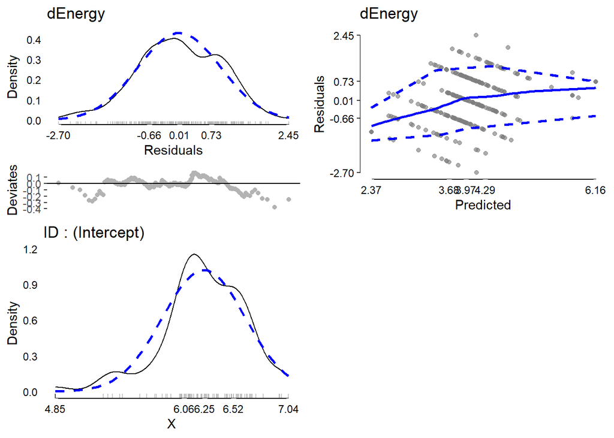

```r
plot(modelDiagnostics(m), nrow = 2, ncol = 2, ask = FALSE)
```

## 3.1 Extra (in case you ever want to fix left skews)

Applying transformations to left skewed data is more difficult as generally transformations work on long right tails. A solution is to reverse the variable, apply the transformation and then again reverse it so that the direction is the same as it originally was. We could try a square root transformations which is milder than a log transformation. To reverse it, we subtract the variable from the sum of its minimum and maximum. Next we take its square root, then we reverse by again subtracting from the sum of its minimum and maximum, but square root transformed.

Let’s sidetrack a little and try this out with an example using a more skewed outcome variable, dMood.

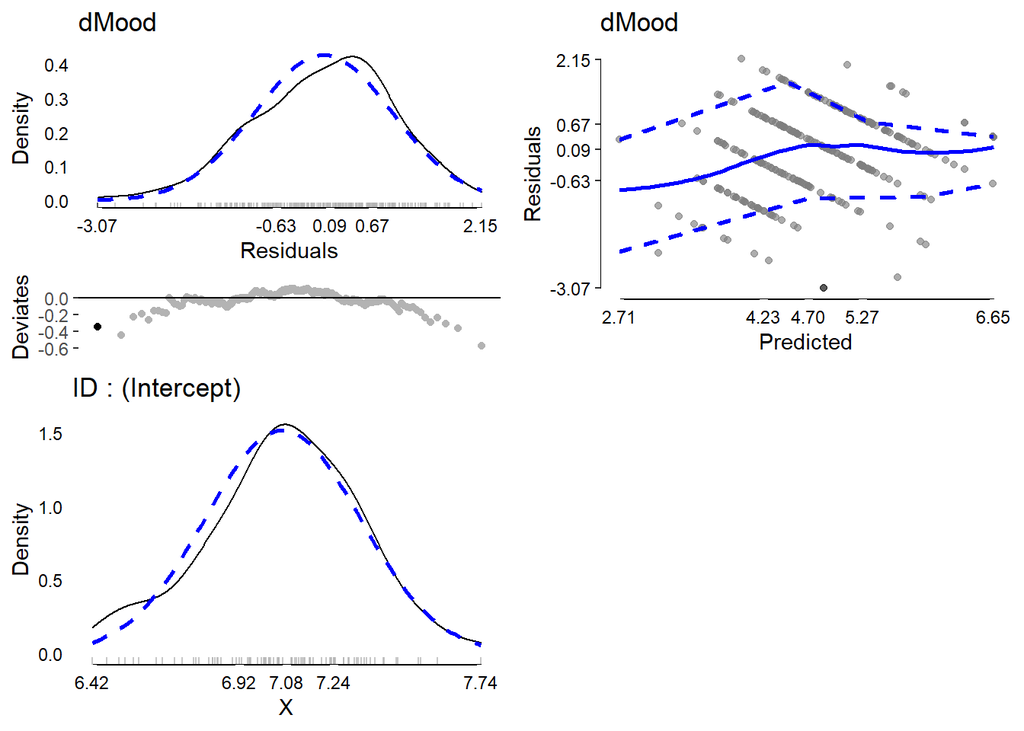

```r
## First let's see how the model looks like with original dMood scores

mtest1 <- lmer(dMood ~ neuroticism * dStress + (1 | ID), data = dm)

mt1 <- modelDiagnostics(mtest1)
plot(mt1, nrow = 2, ncol = 2, ask = FALSE)
```

```r
## Now let's try to fix the very mild left skew just for the sake
## of demonstration

max(dm$dMood) + min(dm$dMood)
```

```
## [1] 8
```

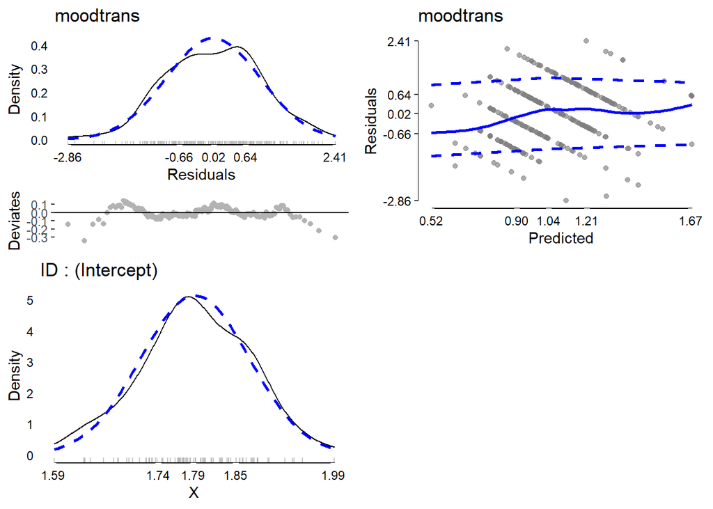

```r
## transform
dm[, moodtrans := sqrt(8) - sqrt(8 - dMood)]

mtest <- lmer(moodtrans ~ neuroticism * dStress + (1 | ID), data = dm)

mt <- modelDiagnostics(mtest)
plot(mt, nrow = 2, ncol = 2, ask = FALSE)
```

The transformation appears to have modestly helped the distribution of residuals. Its not that clear whether it was bad enough to begin with and whether the transformation improved it enough that it is worth the difficulty in interpretation (dMood is now square root transformed and that must be incorporated into its interpretation). For the lecture, we did this for demonstration purposes, but in practice, consider whether this is worth it or only adds difficulty in understanding without improving / changing results much.

Enough sidetracking, let’s go back to our original model, *m*. No extreme value are present. If there were any, we can remove that, as we have discussed in depth in previous lectures, update the model, and re-run diagnostics. In practice it could take a few rounds of extreme value removal or you may decide to stop at one round.

Let’s look at the summary of our model, *m*. Although we have used `summary()` a lot in the past, we’ll introduce another function to help look at `lmer()` model results, `modelTest()`. In this lecture, we will only learn and interpret part of its output, with the rest of the output from `modelTest()` covered later. In addition to get nicely formatted results rather than a set of datasets containing the results, we use the `APAStyler()` function.

```r
APAStyler(modelTest(m))
```

```
## Parameters and CIs are based on REML,
## but modelTests requires ML not REML fit for comparisons,
## and these are used in effect sizes. Refitting.
```

```
##                            Term                     Est           Type
##  1:                 (Intercept)  6.24*** [ 4.93,  7.56]  Fixed Effects
##  2:                     dStress   -0.37* [-0.69, -0.04]  Fixed Effects
##  3:                 neuroticism   -0.49* [-0.88, -0.10]  Fixed Effects
##  4:         neuroticism:dStress     0.07 [-0.03,  0.16]  Fixed Effects
##  5:           sd_(Intercept)|ID                    0.61 Random Effects
##  6:                       sigma                    1.17 Random Effects
##  7:                    Model DF                       6  Overall Model
##  8:                  N (Groups)                 ID (88)  Overall Model
##  9:            N (Observations)                     283  Overall Model
## 10:                      logLik                 -469.35  Overall Model
## 11:                         AIC                  950.70  Overall Model
## 12:                         BIC                  972.57  Overall Model
## 13:                 Marginal R2                    0.09  Overall Model
## 14:                 Marginal F2                    0.10  Overall Model
## 15:              Conditional R2                    0.27  Overall Model
## 16:              Conditional F2                    0.37  Overall Model
## 17:         neuroticism (Fixed)     0.04/0.01, p = .015   Effect Sizes
## 18:             dStress (Fixed)     0.02/0.00, p = .027   Effect Sizes
## 19: neuroticism:dStress (Fixed)     0.01/0.00, p = .160   Effect Sizes
```

The results show the regression coefficients, asterisks for p-values, and 95% confidence intervals in brackets for the fixed effects, the standard deviations of the random effects, the model degrees of freedom, which is how many parameters were estimated in the model total, and the number of people and observations. For now, we will ignore all the output under row 9, N (Observations). In the case of this model we can see the following.

A LMM was fit with 283 observations from 88 people. There was no significant neuroticism x stress interaction, b [95% CI] = 0.07 [-0.03, 0.16], p = .160.

We can also pass multiple model results in a list together, which puts the results side by side. This is particularly helpful for comparing models with and without covariates, to evaluate whether removing extreme values changed the results substantially, or to compare models with different outcomes.

```r
# Remember: m <- lmer(dEnergy ~ neuroticism * dStress + (1 | ID), data = dm)
# mtest1 <- lmer(dMood ~ neuroticism * dStress + (1 | ID), data = dm)

APAStyler(list(
  Energy = modelTest(m),
  Mood = modelTest(mtest1) ))
```

```
## Parameters and CIs are based on REML,
## but modelTests requires ML not REML fit for comparisons,
## and these are used in effect sizes. Refitting.
## Parameters and CIs are based on REML,
## but modelTests requires ML not REML fit for comparisons,
## and these are used in effect sizes. Refitting.
```

```
##                            Term                  Energy                    Mood
##  1:                 (Intercept)  6.24*** [ 4.93,  7.56]  7.07*** [ 6.05,  8.08]
##  2:                     dStress   -0.37* [-0.69, -0.04]  -0.42** [-0.67, -0.17]
##  3:                 neuroticism   -0.49* [-0.88, -0.10]    -0.17 [-0.47,  0.14]
##  4:         neuroticism:dStress     0.07 [-0.03,  0.16]     0.00 [-0.07,  0.07]
##  5:           sd_(Intercept)|ID                    0.61                    0.43
##  6:                       sigma                    1.17                    0.93
##  7:                    Model DF                       6                       6
##  8:                  N (Groups)                 ID (88)                 ID (88)
##  9:            N (Observations)                     283                     283
## 10:                      logLik                 -469.35                 -402.04
## 11:                         AIC                  950.70                  816.09
## 12:                         BIC                  972.57                  837.96
## 13:                 Marginal R2                    0.09                    0.29
## 14:                 Marginal F2                    0.10                    0.41
```

[output cut: 25 more lines]

These results show us that we have similar results when predicting daily energy and daily mood from stress and neuroticism. The relationship between daily stress and daily mood, and daily stress and daily energy did not vary by individual differences in neuroticism. In this case, it would make sense to re-run these models without the interaction term to test the main effects of daily stress and neuroticism.

```r
mmain <- lmer(dEnergy ~ neuroticism + dStress + (1 | ID), data = dm)
mtest1main <- lmer(dMood ~ neuroticism + dStress + (1 | ID), data = dm)

APAStyler(list(
  Energy = modelTest(mmain),
  Mood = modelTest(mtest1main) ))
```

```
## Parameters and CIs are based on REML,
## but modelTests requires ML not REML fit for comparisons,
## and these are used in effect sizes. Refitting.
## Parameters and CIs are based on REML,
## but modelTests requires ML not REML fit for comparisons,
## and these are used in effect sizes. Refitting.
```

```
##                    Term                  Energy                    Mood
##  1:         (Intercept)  5.46*** [ 4.74,  6.17]  7.04*** [ 6.50,  7.59]
##  2:             dStress   -0.15* [-0.27, -0.03] -0.41*** [-0.51, -0.32]
##  3:         neuroticism   -0.24* [-0.42, -0.06]   -0.16* [-0.30, -0.03]
##  4:   sd_(Intercept)|ID                    0.61                    0.43
##  5:               sigma                    1.17                    0.93
##  6:            Model DF                       5                       5
##  7:          N (Groups)                 ID (88)                 ID (88)
##  8:    N (Observations)                     283                     283
##  9:              logLik                 -470.33                 -402.04
## 10:                 AIC                  950.67                  814.09
## 11:                 BIC                  968.90                  832.31
## 12:         Marginal R2                    0.08                    0.29
## 13:         Marginal F2                    0.09                    0.41
## 14:      Conditional R2                    0.27                    0.41
```

[output cut: 21 more lines]

Results are indeed similar for daily mood and energy as outcomes. There are significant negative associations between daily stress and both outcome variables, and also neuroticism and both outcome variables.

## 3.2 Plotting

Typically, to plot our significant interaction, a few exemplar lines are graphed showing the slope of one variable with the outcome at different values of the moderator. As with GLMs, we can use the `visreg()` function. Here, we’ll use neuroticism as the moderator. A common approach to picking level of the moderator is to use the Mean - 1 SD and Mean + 1 SD. To do that, we first need the mean and standard deviation of neuroticism, which we can get using `egltable()` after excluding duplicates by ID, since neuroticism only varies between units. Note that we are doing this for the sake of example only since our interaction was not signficant.

```r
egltable(c("neuroticism"), data = dm[!duplicated(ID)])
```

```
##                     M (SD)
## 1: neuroticism 3.46 (1.11)
```

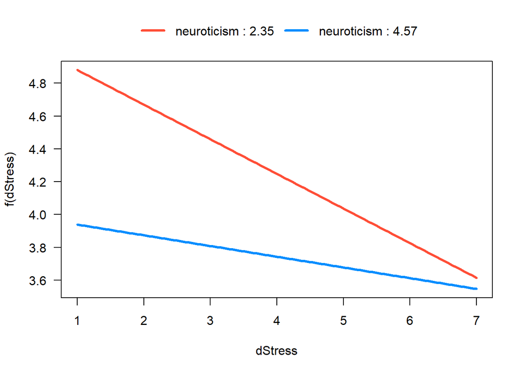

```r
visreg(m, xvar = "dStress",
       by = "neuroticism", overlay=TRUE,
       breaks = c(3.46-1.11, 3.46+1.11),
       partial = FALSE, rug = FALSE)
```

The results show, in an easier to interpret way, what the positive interaction coefficient of $b = 0.07$ means, people with higher levels of neuroticism are less sensitive to the (negative) effects of stress. People higher in neuroticism are relatively less sensitive to the effects of stress, although in both cases, higher stress is associated with lower energy levels. Keep in mind again that we are interpreting this as though the interaction was signficant for the sake of example only.

Another common way of picking some exemplar values is to use the 25th and 75th percentiles. These work particularly well for very skewed distributions where the mean +/- SD could be outside the observed range of the data. Again we exclude duplicates by ID and then use the `quantile()` function to get the values, 3, and 4.5 for the 25th and 75th percentiles.

```r
quantile(dm[!duplicated(ID), neuroticism], na.rm = TRUE)
```

```
##   0%  25%  50%  75% 100%
##  1.0  3.0  3.5  4.5  5.0
```

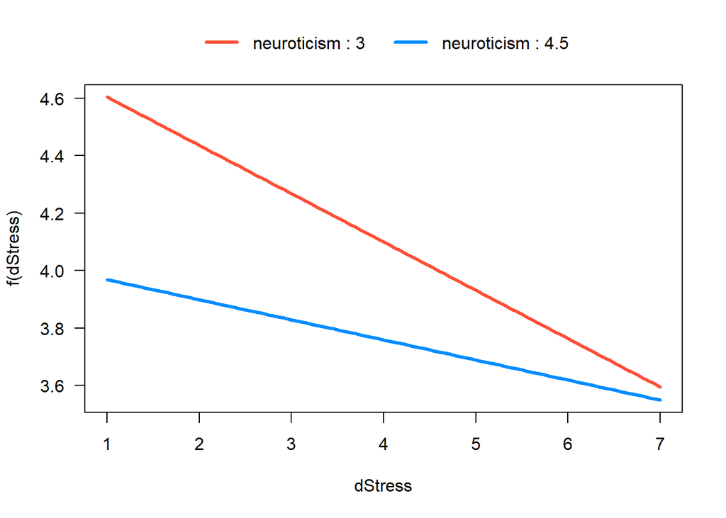

```r
visreg(m, xvar = "dStress",
       by = "neuroticism", overlay=TRUE,
       breaks = c(3, 4.5),
       partial = FALSE, rug = FALSE)
```

## 3.3 Simple Effects

When working with models that have interactions, a common aid to interpretation is to test the simple effects / slopes from the model. For example, previously we graphed the association between stress and energy at M - 1 SD and M + 1 SD on neuroticism. However, although visually both lines appeared to have a negative slope, we do not know from the graph alone whether there is a significant association between stress and energy at both the low (M - 1 SD) and high (M + 1 SD) levels of neuroticism. To answer that, we need to test the simple slope of stress at specific values of neuroticism. Again this is for demonstration only given our non- significant moderation. We would not need to compute simple slopes or effects for non-significant moderations in reality.

Our default model does actually give us one simple slope: it is the simple slope of stress when $neuroticism = 0$. However, as we can tell from the mean and standard deviation of neuroticism, 0 is very far outside the plausible range of values so that simple slope given to us by default from the model is not too useful. We could either center neuroticism and re-run the model, which would get us a different simple slope, or use post hoc functions to calculate simple slopes.

We will use the `emtrends()` function from the `emmeans` package to test the simple slopes. This function also works with GLMs, for your reference.

The `emtrends()` function take a model as its first argument, then the variable that you want to calculate a simple slope for, here `stress`, the argument `at` requires a list of specific values of the moderator, and then we tell it how we want degrees of freedom calculated (note this only applies to `lmer` models). We store the results in an `R` object, `mem` and then call `summary()` to get a summary table. The `infer = TRUE` argument is needed in `summary()` if you want p-values.

```r
mem <- emtrends(m, var = "dStress",
                at = list(neuroticism = c(3.46-1.11, 3.46+1.11)),
                lmer.df = "satterthwaite")

summary(mem, infer=TRUE)
```

```
##  neuroticism dStress dStress.trend     SE  df lower.CL upper.CL t.ratio p.value
##         2.35    4.13       -0.2109 0.0743 213   -0.357  -0.0644 -2.838  0.0050
##         4.57    4.13       -0.0653 0.0858 263   -0.234   0.1036 -0.761  0.4472
##
## Degrees-of-freedom method: satterthwaite
## Confidence level used: 0.95
```

The relevant parts of the output, for us, are the columns for `stress.trend` which are the simple slopes, the values of `neuroticism` which tell us at what values of neuroticism we have calculated simple slopes, the confidence intervals, `lower.CL` and `upper.CL`, 95% by default, and the p-value. From these results, we can see that when $neuroticism = 2.35$ there is a significant negative association between stress and energy, but not when $neuroticism = 4.57$.

## 3.4 Sample Write Up

With all of this information, we can plan out some final steps for a polished write up of the results. First, let’s get exact p-values for all our results. We can do this through options to `pcontrol` in `APAStyler()`. We also re-print the simple slopes here.

```r
APAStyler(modelTest(m),
  pcontrol = list(digits = 3, stars = FALSE, includeP = TRUE,
                  includeSign = TRUE, dropLeadingZero = TRUE))
```

```
## Parameters and CIs are based on REML,
## but modelTests requires ML not REML fit for comparisons,
## and these are used in effect sizes. Refitting.
```

```
##                            Term                          Est           Type
##  1:                 (Intercept)  6.24p < .001 [ 4.93,  7.56]  Fixed Effects
##  2:                     dStress -0.37p = .029 [-0.69, -0.04]  Fixed Effects
##  3:                 neuroticism -0.49p = .016 [-0.88, -0.10]  Fixed Effects
##  4:         neuroticism:dStress  0.07p = .166 [-0.03,  0.16]  Fixed Effects
##  5:           sd_(Intercept)|ID                         0.61 Random Effects
##  6:                       sigma                         1.17 Random Effects
##  7:                    Model DF                            6  Overall Model
##  8:                  N (Groups)                      ID (88)  Overall Model
##  9:            N (Observations)                          283  Overall Model
## 10:                      logLik                      -469.35  Overall Model
## 11:                         AIC                       950.70  Overall Model
## 12:                         BIC                       972.57  Overall Model
## 13:                 Marginal R2                         0.09  Overall Model
## 14:                 Marginal F2                         0.10  Overall Model
## 15:              Conditional R2                         0.27  Overall Model
## 16:              Conditional F2                         0.37  Overall Model
## 17:         neuroticism (Fixed)          0.04/0.01, p = .015   Effect Sizes
## 18:             dStress (Fixed)          0.02/0.00, p = .027   Effect Sizes
## 19: neuroticism:dStress (Fixed)          0.01/0.00, p = .160   Effect Sizes
```

```r
summary(mem, infer=TRUE)
```

```
##  neuroticism dStress dStress.trend     SE  df lower.CL upper.CL t.ratio p.value
##         2.35    4.13       -0.2109 0.0743 213   -0.357  -0.0644 -2.838  0.0050
##         4.57    4.13       -0.0653 0.0858 263   -0.234   0.1036 -0.761  0.4472
##
## Degrees-of-freedom method: satterthwaite
## Confidence level used: 0.95
```

Now we will make a polished, finalized figure. I have customized the colours, and turned off the legends. In place of legends, I have manually added text annotations including the simple slopes and confidence intervals and p-values for the simple slopes.

For your reference, it took about 8 trial and errors of different x and y values and angles to get the text to line up about right. I did not magically get the values to use to get a graph that I thought looked nice. That is why I think sometimes it is easier to add this sort of text after the fact in your slides or papers rather than building it into the code.

```r
visreg(m, xvar = "dStress",
       by = "neuroticism", overlay=TRUE,
       breaks = c(3.46-1.11, 3.46+1.11),
       partial = FALSE, rug = FALSE, gg=TRUE,
       xlab = "Daily Stress",
       ylab = "Predicted Daily Energy") +
  scale_color_manual(values = c("2.35" = "black", "4.57" = "grey70")) +
  theme_pubr() +
  guides(colour = FALSE, fill = FALSE) +
  annotate(geom = "text", x = 3.2, y = 3.9, label = "High Neuroticism: b = -0.07 [-0.23, 0.10], p = .447",
           angle = -12) +
  annotate(geom = "text", x = 4, y = 4.4, label = "Low Neuroticism: b = -0.21 [-0.36, -0.06], p = .005",
           angle = -33)
```

[output not shown]

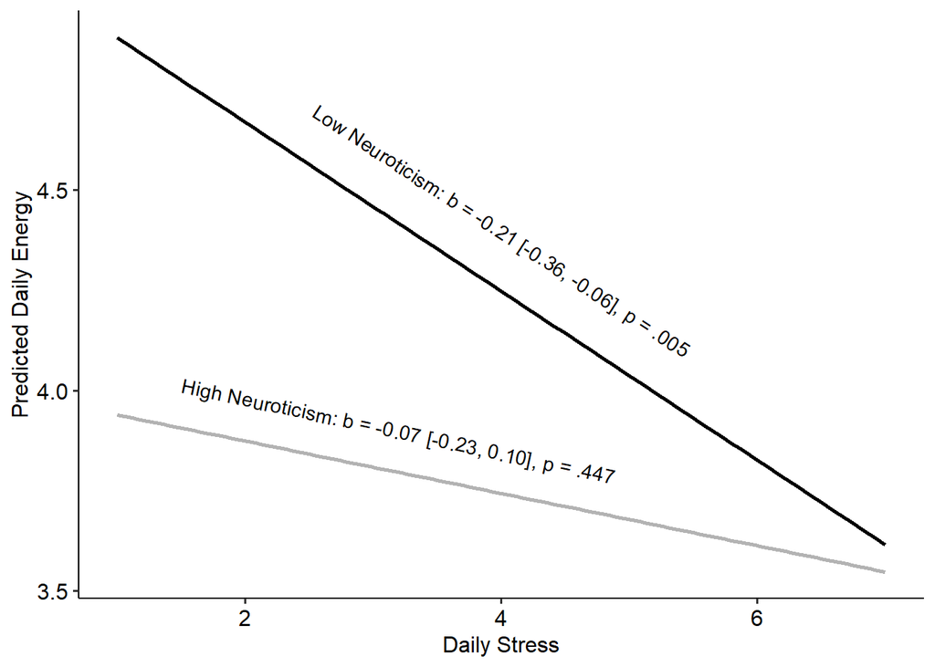

A linear mixed model using restricted maximum likelihood was used to test whether the association of daily stress on daily energy is moderated by baseline neuroticism scores. All predictors were included as fixed effects and a random intercept by participant was included. Visual diagnostics showed that energy was normally distributed, and no outliers were present.

The daily stress x neuroticism interaction was not statistically significant, which indicated that the relationship between stress and energy did not vary by neuroticism. Results from the analysis with the interaction dropped revealed that both neuroticism and daily stress were negatively associated with daily energy.

# 4 Continuous x Categorical Interactions in `R`

Continuous x Categorical interactions are conducted much as continuous x continuous interactions. Typically with continuous x categorical interactions, simple slopes for the continuous variable are calculated at all levels of the categorical variable.

Let’s illustrate this with a model examining the relationship between daily energy levels and self-esteem with sex as a moderator.

```r
mconcat<- lmer(dSE ~ dEnergy*sex + (1| ID), data = dm)
```

The model diagnostics look relatively good, albeit not perfect.

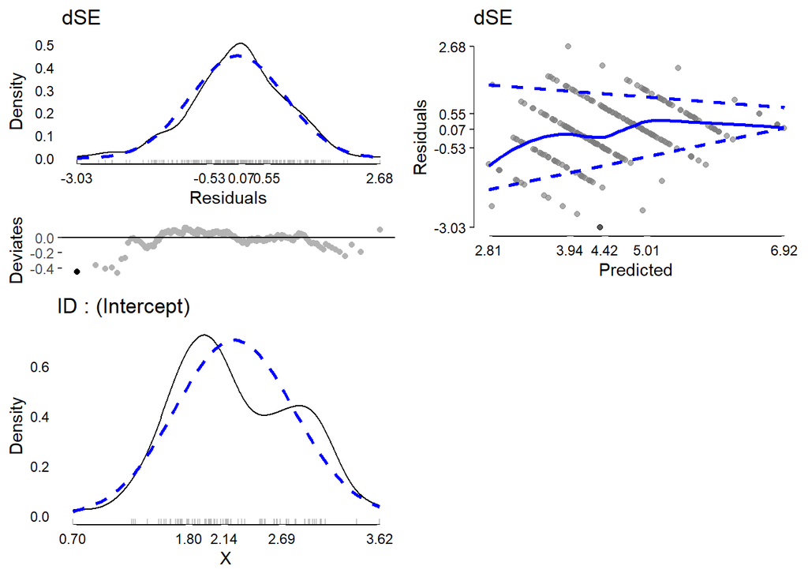

```r
plot(modelDiagnostics(mconcat), nrow = 2, ncol = 2, ask = FALSE)
```

With reasonable diagnostics, we can look at a summary. There is one extreme residual but I’m choosing to leave it in the dataset.

```r
summary(mconcat)
```

```
## Linear mixed model fit by REML. t-tests use Satterthwaite's method [
## lmerModLmerTest]
## Formula: dSE ~ dEnergy * sex + (1 | ID)
##    Data: dm
##
## REML criterion at convergence: 771.8
##
## Scaled residuals:
##     Min      1Q  Median      3Q     Max
## -3.0275 -0.5344  0.0658  0.5515  2.6785
##
## Random effects:
##  Groups   Name        Variance Std.Dev.
##  ID       (Intercept) 0.489    0.699
##  Residual             0.607    0.779
## Number of obs: 282, groups:  ID, 88
##
## Fixed effects:
##                   Estimate Std. Error      df t value Pr(>|t|)
## (Intercept)          2.235      0.564 269.175    3.96  9.4e-05 ***
## dEnergy              0.619      0.120 273.898    5.16  4.9e-07 ***
## sexfemale            0.878      0.600 268.799    1.46    0.144
## dEnergy:sexfemale   -0.274      0.128 272.789   -2.13    0.034 *
## ---
## Signif. codes:  0 '***' 0.001 '**' 0.01 '*' 0.05 '.' 0.1 ' ' 1
##
## Correlation of Fixed Effects:
##             (Intr) dEnrgy sexfml
## dEnergy     -0.907
## sexfemale   -0.940  0.853
## dEnrgy:sxfm  0.850 -0.937 -0.904
```

Factor variables in interactions do not work currently with `modelTest()`, so if we wanted to use it, we’d need to manually dummy code the categorical variable. The results are identical.

```r
dm[, female := as.integer(sex == "female")]

malt <- lmer(dSE ~ dEnergy * female + (1 | ID), data = dm)

APAStyler(modelTest(malt))
```

```
## Parameters and CIs are based on REML,
## but modelTests requires ML not REML fit for comparisons,
## and these are used in effect sizes. Refitting.
```

```
##                       Term                     Est           Type
##  1:            (Intercept)  2.23*** [ 1.13,  3.34]  Fixed Effects
##  2:                dEnergy  0.62*** [ 0.38,  0.85]  Fixed Effects
##  3:         dEnergy:female   -0.27* [-0.53, -0.02]  Fixed Effects
##  4:                 female     0.88 [-0.30,  2.05]  Fixed Effects
##  5:      sd_(Intercept)|ID                    0.70 Random Effects
##  6:                  sigma                    0.78 Random Effects
##  7:               Model DF                       6  Overall Model
##  8:             N (Groups)                 ID (88)  Overall Model
##  9:       N (Observations)                     282  Overall Model
## 10:                 logLik                 -380.57  Overall Model
## 11:                    AIC                  773.14  Overall Model
## 12:                    BIC                  794.99  Overall Model
## 13:            Marginal R2                    0.23  Overall Model
## 14:            Marginal F2                    0.29  Overall Model
## 15:         Conditional R2                    0.56  Overall Model
## 16:         Conditional F2                    1.30  Overall Model
## 17:        dEnergy (Fixed)     0.09/0.15, p < .001   Effect Sizes
## 18:         female (Fixed)     0.00/0.01, p = .144   Effect Sizes
## 19: dEnergy:female (Fixed)     0.02/0.05, p = .035   Effect Sizes
```

## 4.1 Plotting

With continuous x categorical interactions, the easiest approach is to plot the simple slope of the continuous variable by the categorical one as shown in the following.

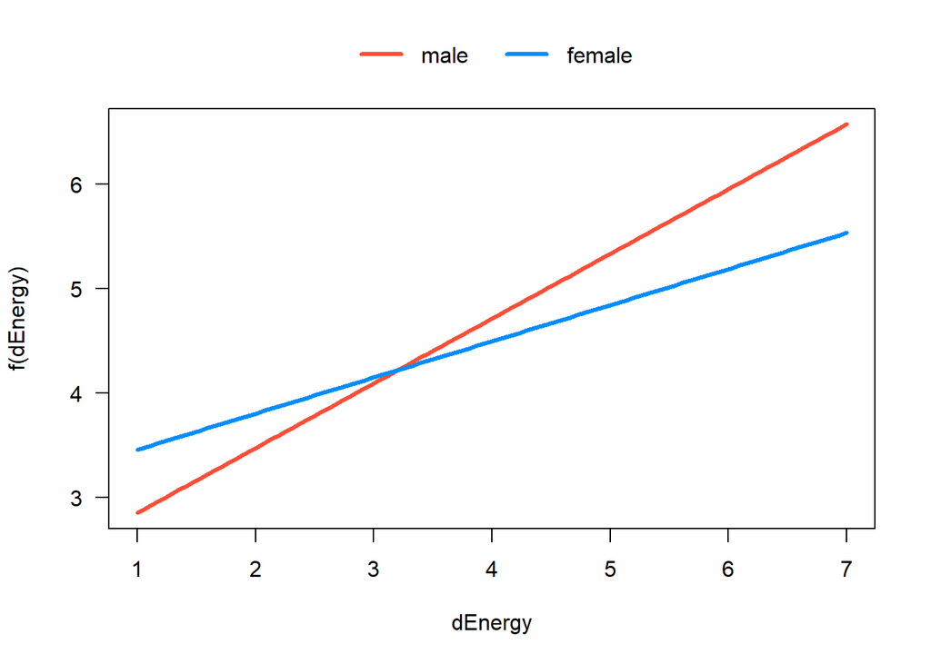

```r
visreg(mconcat, xvar = "dEnergy",
       by = "sex", overlay=TRUE,
       partial = FALSE, rug = FALSE)
```

```r
## EXTRA: another example using a different
## model with continuous variable as moderator
egltable(c("conscientiousness"), data = dm[!duplicated(ID)])
```

```
##                           M (SD)
## 1: conscientiousness 3.76 (0.86)
```

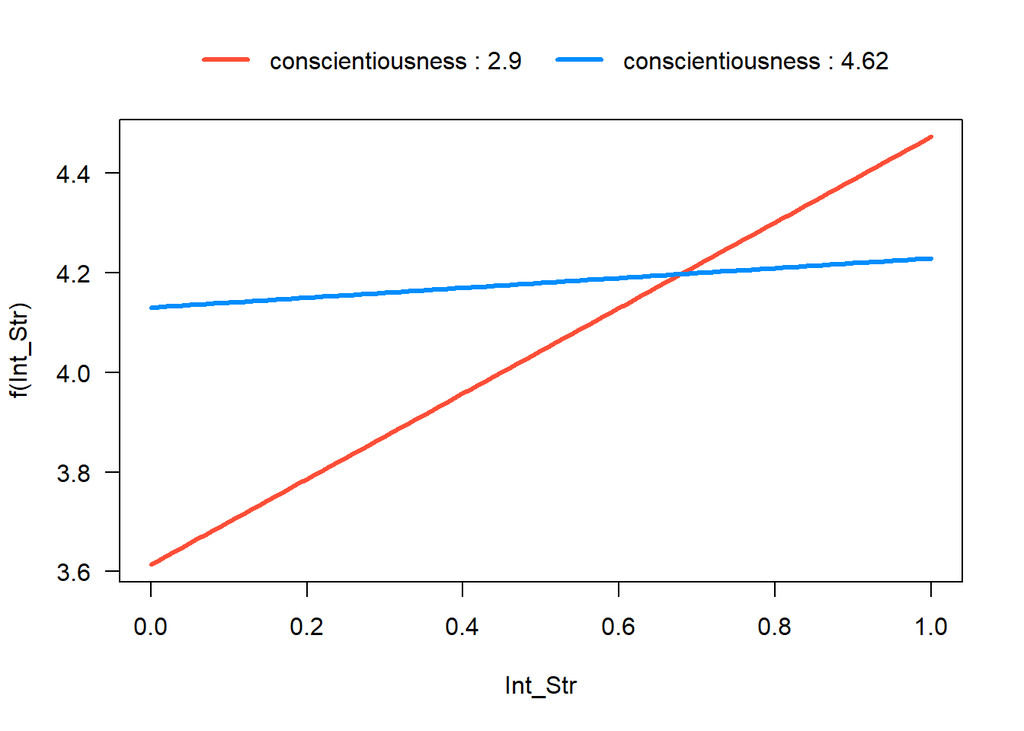

```r
visreg(m2, xvar = "Int_Str",
       by = "conscientiousness", overlay=TRUE,
       breaks = c(3.76-0.86, 3.76+0.86),
       partial = FALSE, rug = FALSE)
```

## 4.2 Simple Effects

When working with models that have interactions, a common aid to interpretation is to test the simple effects / slopes from the model. For example, previously we graphed the association between daily energy and self-esteem at each level of the categorical `sex` variable, i.e. for men and women. However, we cannot tell from the graph whether daily energy is significantly associated with self-esteem for men or women.

To answer that, we need to test the simple slope of energy at the two sex levels. Our default model does actually give us one simple slope: it is the simple slope of energy when for men (i.e when female = 0), but we might want more.

We will use the `emtrends()` function from the `emmeans` package to test the simple slopes.

The `emtrends()` function take a model as its first argument, then the variable that you want to calculate a simple slope for, here `energy`, the argument `at` requires a list of specific values of the moderator, and then we tell it how we want degrees of freedom calculated (note this only applies to `lmer` models). We store the results in an `R` object, `mem` and then call `summary()` to get a summary table. The `infer = TRUE` argument is needed in `summary()` if you want p-values.

```r
mem <- emtrends(mconcat, var = "dEnergy",
                at = list(sex = c("male", "female")),
                lmer.df = "satterthwaite")

summary(mem, infer=TRUE)
```

```
##  dEnergy sex    dEnergy.trend     SE  df lower.CL upper.CL t.ratio p.value
##        4 male           0.619 0.1201 274    0.383    0.856 5.155   <.0001
##        4 female         0.346 0.0449 261    0.257    0.434 7.689   <.0001
##
## Degrees-of-freedom method: satterthwaite
## Confidence level used: 0.95
```

The relevant parts of the output, for us, are the columns for `dEnergy.trend` which are the simple slopes, the values of `sex` which tell us at what values of sex we have calculated simple slopes, the confidence intervals, `lower.CL` and `upper.CL`, 95% by default, and the p-value. From these results, we can see that daily energy is significantly associated with self-esteem for any sex, although it is stronger for men than women.

# 5 Categorical x Categorical Interactions in `R`

Categorical x Categorical interactions are conducted comparably, although more contrasts / simple effect follow-ups are possible.

Here we will work with Int_Str again, which is a two-level categorical predictor (0 = no interaction with a stranger, 1 = interacted with a stranger that day) and energy as the outcome. We also work with a three-level conscientiousness variable.

```r
## create a categorical conscientiousness variable
dm[, cons3 := cut(conscientiousness, breaks = quantile(conscientiousness, probs = c(0, 1/3, 2/3, 1), na.rm=TRUE),
                    labels = c("Low", "Mid", "High"),
                    include.lowest = TRUE)]

mcat2 <- lmer(dEnergy ~ cons3 * Int_Str + (1 | ID), data = dm)
```

The model diagnostics look relatively good.

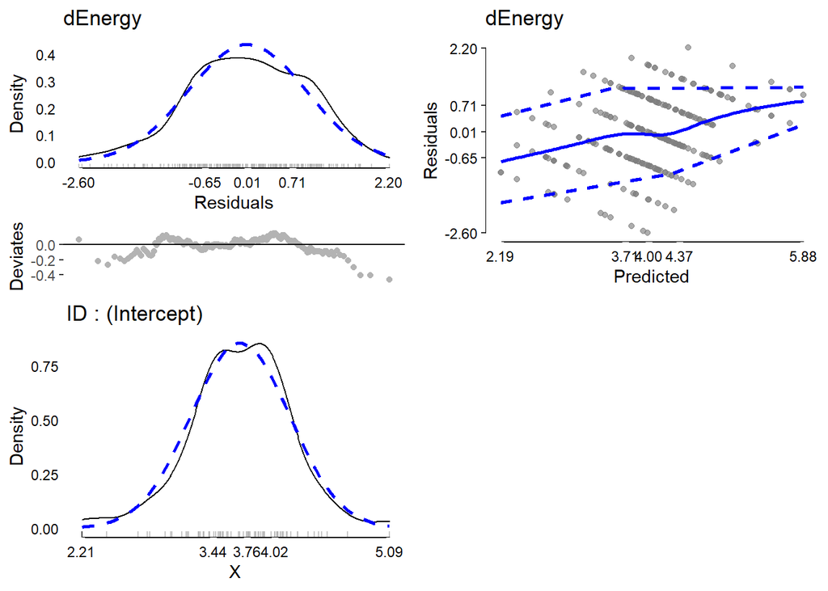

```r
plot(modelDiagnostics(mcat2), nrow = 2, ncol = 2, ask = FALSE)
```

With reasonable diagnostics, we can look at a summary.

```r
summary(mcat2)
```

```
## Linear mixed model fit by REML. t-tests use Satterthwaite's method [
## lmerModLmerTest]
## Formula: dEnergy ~ cons3 * Int_Str + (1 | ID)
##    Data: dm
##
## REML criterion at convergence: 943.9
##
## Scaled residuals:
##     Min      1Q  Median      3Q     Max
## -2.6025 -0.6516  0.0136  0.7113  2.2028
##
## Random effects:
##  Groups   Name        Variance Std.Dev.
##  ID       (Intercept) 0.464    0.681
##  Residual             1.315    1.147
## Number of obs: 283, groups:  ID, 88
##
## Fixed effects:
##                   Estimate Std. Error       df t value Pr(>|t|)
## (Intercept)         3.6934     0.1635 118.5695   22.59  < 2e-16 ***
## cons3Mid           -0.0514     0.3064  97.6260   -0.17  0.86716
## cons3High           0.6270     0.2645 119.6594    2.37  0.01935 *
## Int_Str             0.7898     0.2317 266.3274    3.41  0.00075 ***
## cons3Mid:Int_Str   -0.9873     0.5050 272.8990   -1.96  0.05157 .
## cons3High:Int_Str  -0.6233     0.3791 276.2360   -1.64  0.10128
## ---
## Signif. codes:  0 '***' 0.001 '**' 0.01 '*' 0.05 '.' 0.1 ' ' 1
##
## Correlation of Fixed Effects:
##             (Intr) cns3Md cns3Hg Int_St c3M:I_
## cons3Mid    -0.534
## cons3High   -0.618  0.330
## Int_Str     -0.446  0.238  0.276
## cns3Md:In_S  0.205 -0.375 -0.127 -0.459
## cns3Hgh:I_S  0.273 -0.146 -0.462 -0.611  0.280
```

## 5.1 Plotting

With categorical x categorical interactions, `visreg()` produces OK but not great figures as shown in the following. We can see the means of energy for all 6 cells (the cross of 3 level of conscientiousness x 2 levels of Int_Str).

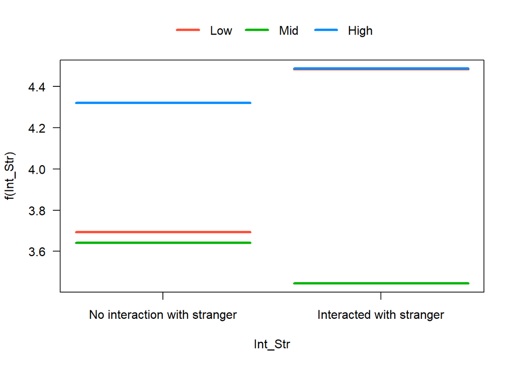

```r
 dm[, Int_Str := factor(
  Int_Str,
  levels = c(0,1),
  labels = c("No interaction with stranger", "Interacted with stranger"))]

visreg(mcat2, xvar = "Int_Str",
       by = "cons3", overlay=TRUE,
       partial = FALSE, rug = FALSE)
```

## 5.2 Simple Effects

When working with two categorical interactions (or with a categorical predictor with >2 levels where you want to test various group differences), the `emmeans()` function from the `emmeans` package is helpful. We can get the means of interaction with stranger by conscientiousness group and get confidence intervals and p-values. These p-values test whether each mean is different from zero, by default.

```r
## re-run mcat2 now with int_str as factor
mcat2 <- lmer(dEnergy ~ cons3 * Int_Str + (1 | ID), data = dm)

em <- emmeans(mcat2, "Int_Str", by = "cons3",
              lmer.df = "satterthwaite")
summary(em, infer = TRUE)
```

```
## cons3 = Low:
##  Int_Str                      emmean    SE    df lower.CL upper.CL t.ratio
##  No interaction with stranger   3.69 0.164 118.6     3.37     4.02 22.586
##  Interacted with stranger       4.48 0.216 212.4     4.06     4.91 20.770
##  p.value
##  <.0001
##  <.0001
##
## cons3 = Mid:
##  Int_Str                      emmean    SE    df lower.CL upper.CL t.ratio
##  No interaction with stranger   3.64 0.259  90.5     3.13     4.16 14.058
##  Interacted with stranger       3.44 0.432 245.6     2.59     4.29  7.981
##  p.value
##  <.0001
##  <.0001
##
## cons3 = High:
##  Int_Str                      emmean    SE    df lower.CL upper.CL t.ratio
##  No interaction with stranger   4.32 0.208 120.3     3.91     4.73 20.784
##  Interacted with stranger       4.49 0.273 183.0     3.95     5.03 16.446
##  p.value
##  <.0001
##  <.0001
##
## Degrees-of-freedom method: satterthwaite
## Confidence level used: 0.95
```

A nice plot, with confidence intervals for the fixed effects, can be obtained by using the `emmip()` function from the `emmeans` package. It takes as input the results from `emmeans()`, not the `lmer()` model results directly. Here is a simple plot showing the categorical interactions. Note that with this approach, you could basically fit the same model(s) that you would with a repeated measures or mixed effects ANOVA model, with the advantage that LMMs do not require balanced designs and allow both categorical and continuous predictors (e.g., you could include continuous covariates easily). GLMs and (G)LMMs can do everything that t-tests and various ANOVAs can, but with greater flexibility.

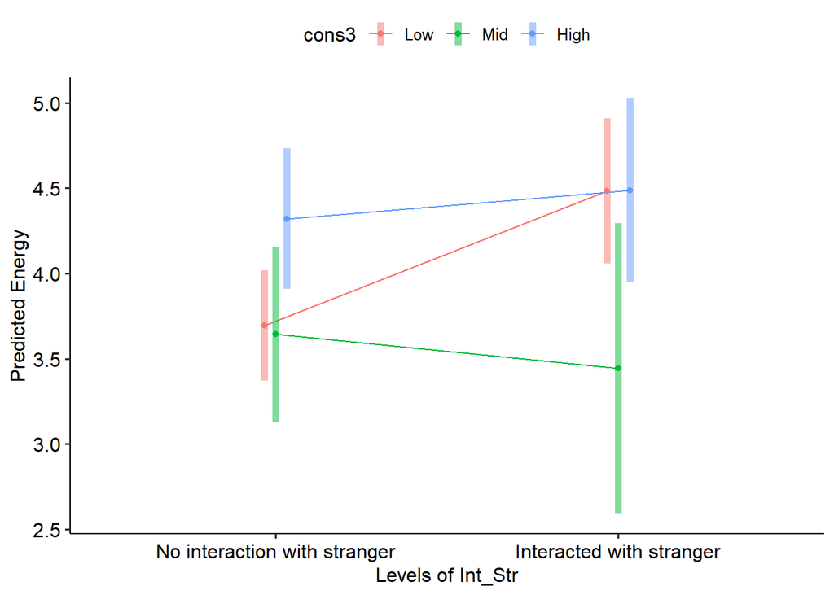

```r
emmip(em, cons3~Int_Str, CIs = TRUE) +
  theme_pubr() +
  ylab("Predicted Energy")
```

If you want pairwise comparisons, you can get all possible pairwise comparisons between stranger interaction levels by conscientiousness using the `pairs()` function.

```r
## pairwise comparisons of Int_Str by conscientiousness
pairs(em, by = "cons3")
```

```
## cons3 = Low:
##  contrast                                                estimate    SE  df
##  No interaction with stranger - Interacted with stranger   -0.790 0.232 266
##  t.ratio p.value
##  -3.409  0.0008
##
## cons3 = Mid:
##  contrast                                                estimate    SE  df
##  No interaction with stranger - Interacted with stranger    0.198 0.449 274
##  t.ratio p.value
##   0.440  0.6601
##
## cons3 = High:
##  contrast                                                estimate    SE  df
##  No interaction with stranger - Interacted with stranger   -0.166 0.300 277
##  t.ratio p.value
##  -0.555  0.5796
##
## Degrees-of-freedom method: satterthwaite
```

```r
## pairwise comparisons of conscientiousness by Int_Str
pairs(em, by = "Int_Str")
```

```
## Int_Str = No interaction with stranger:
##  contrast   estimate    SE    df t.ratio p.value
##  Low - Mid    0.0514 0.306  97.6  0.168  0.9846
##  Low - High  -0.6270 0.265 119.7 -2.371  0.0503
##  Mid - High  -0.6784 0.332 101.0 -2.042  0.1074
##
## Int_Str = Interacted with stranger:
##  contrast   estimate    SE    df t.ratio p.value
##  Low - Mid    1.0387 0.482 239.4  2.152  0.0817
##  Low - High  -0.0037 0.348 194.2 -0.010  0.9999
##  Mid - High  -1.0424 0.511 228.6 -2.042  0.1047
##
## Degrees-of-freedom method: satterthwaite
## P value adjustment: tukey method for comparing a family of 3 estimates
```

You can also get custom contrasts. For example, if we wanted to compare high conscientiousness to the average of low and mid conscientiousness at each level of sex (H1) and secondly see if low and mid conscientiousness differ (H2). The list gives the specific contrast weights, which are directly applied to the means we obtain from `emmeans()`.

```r
## First let's run the model examining whether the
## association between conscientiousness and energy
## is moderated by sex
mcat22 <- lmer(dEnergy ~ cons3 * sex + (1 | ID), data = dm)

## Get the means for each group
em2 <- emmeans(mcat22, "cons3", by = "sex",
              lmer.df = "satterthwaite")
summary(em2, infer = TRUE)
```

```
## sex = male:
##  cons3 emmean    SE   df lower.CL upper.CL t.ratio p.value
##  Low     4.08 0.423 80.0     3.24     4.92  9.651  <.0001
##  Mid     4.11 0.476 78.2     3.16     5.06  8.625  <.0001
##  High    4.80 0.524 69.6     3.76     5.85  9.168  <.0001
##
## sex = female:
##  cons3 emmean    SE   df lower.CL upper.CL t.ratio p.value
##  Low     3.92 0.158 84.2     3.61     4.24 24.744  <.0001
##  Mid     3.42 0.287 73.9     2.85     3.99 11.912  <.0001
##  High    4.31 0.199 85.0     3.92     4.71 21.686  <.0001
##
## Degrees-of-freedom method: satterthwaite
## Confidence level used: 0.95
```

```r
## Apply the custom contrasts
contrast(em2,
         list(
           H1 = c(.5, .5, -1),
           H2 = c(1, -1, 0)),
         by = "sex")
```

```
## sex = male:
##  contrast estimate    SE   df t.ratio p.value
##  H1        -0.7072 0.613 72.0 -1.154  0.2525
##  H2        -0.0241 0.637 79.0 -0.038  0.9699
##
## sex = female:
##  contrast estimate    SE   df t.ratio p.value
##  H1        -0.6426 0.258 81.2 -2.493  0.0147
##  H2         0.5044 0.328 76.1  1.538  0.1281
##
## Degrees-of-freedom method: satterthwaite
```

To help you see directly how the contrast weights are applied, we can apply them directly to the estimated means.

```r
## all the means
as.data.frame(em2)
```

```
##   cons3    sex emmean     SE    df lower.CL upper.CL
## 1   Low   male  4.083 0.4231 80.00    3.241    4.925
## 2   Mid   male  4.108 0.4762 78.24    3.159    5.056
## 3  High   male  4.803 0.5239 69.58    3.758    5.848
## 4   Low female  3.922 0.1585 84.15    3.607    4.238
## 5   Mid female  3.418 0.2869 73.86    2.846    3.990
## 6  High female  4.313 0.1989 84.97    3.917    4.708
```

```r
## just the first three, all for sex = male
as.data.frame(em2)$emmean[1:3]
```

```
## [1] 4.083 4.108 4.803
```

```r
## apply H1 weights
sum(as.data.frame(em2)$emmean[1:3] * c(.5, .5, -1))
```

```
## [1] -0.7072
```

```r
## apply H2 weight
sum(as.data.frame(em2)$emmean[1:3] * c(1, -1, 0))
```

```
## [1] -0.0241
```

```r
## all the means
as.data.frame(em2)
```

```
##   cons3    sex emmean     SE    df lower.CL upper.CL
## 1   Low   male  4.083 0.4231 80.00    3.241    4.925
## 2   Mid   male  4.108 0.4762 78.24    3.159    5.056
## 3  High   male  4.803 0.5239 69.58    3.758    5.848
## 4   Low female  3.922 0.1585 84.15    3.607    4.238
## 5   Mid female  3.418 0.2869 73.86    2.846    3.990
## 6  High female  4.313 0.1989 84.97    3.917    4.708
```

```r
contrast(em,
         list(
           H1 = c(.5, 0, 0, .5, 0, -1)),
         by = NULL)
```

```
##  contrast estimate    SE  df t.ratio p.value
##  H1         -0.918 0.357 202 -2.569  0.0109
##
## Degrees-of-freedom method: satterthwaite
```

# 6 Summary

## 6.1 Conceptual

Key points to take away conceptually are:

- How to include interactions/moderation in LMMs
- How to understand whether there is a significant interaction or notation
- How to test and interpret interactions
- How to test simple slopes / simple effects from different kinds of interactions

## 6.2 Code

| Function | What it does |
| --- | --- |
| `lmer()` | estimate a LMM |
| `confint()` | calculate confidence intervals for a LMM |
| `visreg()` | create marginal or conditional graphs from a LMM |
| `modelDiagnostics()` | evaluate model diagnostics for LMMs including of multivariate normality |
| `summary()` | get a summary of model results |
| `modelTest()` | along with `APAStyler()` get a nicely formatted summary of a model results. |
| `emmeans()` | test specific means from a model. |
| `emtrends()` | test simple slopes from a model. |
| `contrast()` | test custom contrasts on a set of means from `emmeans()`. |